# Stroke analysis and prediction

We use a stratified split from caret to keep the ratio of patients that had and didn’t have a stroke in all datasets the same, this is important since we have few patients that had a stroke and they could all end up in one side after the split.

```r
data$stroke <- as.factor(data$stroke)

train.index <- createDataPartition(data$stroke, p = 0.75, list = FALSE)
tmp_train <- data[ train.index,]
tb_test  <- data[-train.index,]

train_2.index <- createDataPartition(tmp_train$stroke, p = 0.75, list = FALSE)
tb_val  <- tmp_train[-train_2.index,]
tb_train <- tmp_train[ train_2.index,]

print(glue("Train set shape: ({dim(tb_train)[[1]]}, {dim(tb_train)[[2]]})"))
```

```
Train set shape: (2762, 11)
```

```r
print(glue("Validation set shape: ({dim(tb_val)[[1]]}, {dim(tb_val)[[2]]})"))
```

```
Validation set shape: (920, 11)
```

```r
print(glue("Test set shape: ({dim(tb_test)[[1]]}, {dim(tb_test)[[2]]})"))
```

```
Test set shape: (1227, 11)
```

We can start doing some data exploration. Let’s start by understanding the numeric variables, we don’t have many of them in this dataset as most of them are either binary or categorical. The options are age, bmi and avg_glucose_level.

```r
numeric_columns <- c('age','avg_glucose_level','bmi')

print(summary(select(tb_train, all_of(numeric_columns))))
```

```
      age        avg_glucose_level      bmi
 Min.   : 0.08   Min.   : 55.25    Min.   :11.30
 1st Qu.:26.00   1st Qu.: 77.06    1st Qu.:23.80
 Median :45.00   Median : 91.89    Median :28.20
 Mean   :43.32   Mean   :105.53    Mean   :28.93
 3rd Qu.:60.00   3rd Qu.:113.28    3rd Qu.:33.10
 Max.   :82.00   Max.   :271.74    Max.   :71.90
```

We plot their PDFs to understand their distributions.

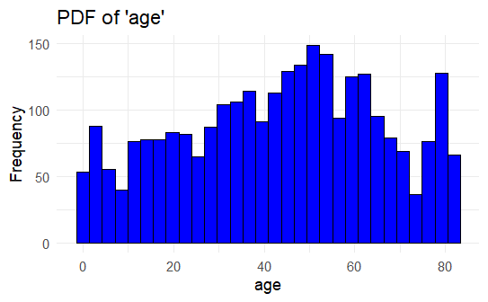

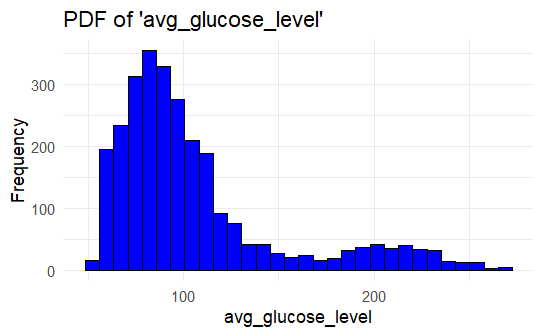

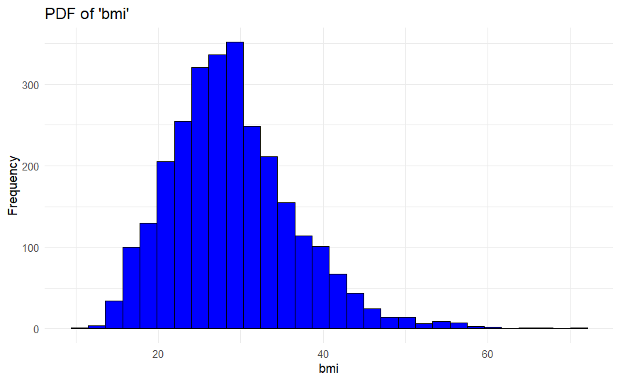

```r
for (col in numeric_columns) {
  p <- ggplot(tb_train, aes(x = !!sym(col))) +
    geom_histogram(bins = 30, fill = "blue", color = "black") +
    labs(title = glue("PDF of '{col}'"), x = col, y = "Frequency") +
    theme_minimal()
  print(p)
}
```

From the PDF of age we can see that our dataset is quite varied with many patients coming from all age ranges. Although there are a few peaks around the mean, it isn’t really a normal distribution. Bmi on the other hand shows a well-defined bell shape centered around 29, it is slightly right-skewed and some outliers can be noticed. The PDF of the glucose level is the most interesting one as we can notice a separation between values before 175~ and after, it looks like two normal distributions put together as the points far from the ‘first bell’ are quite a lot.

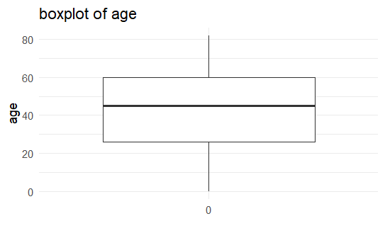

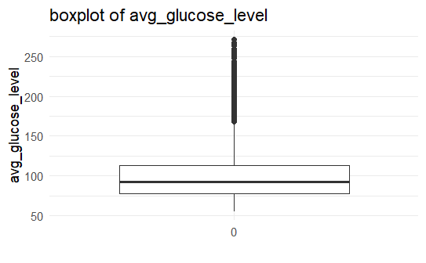

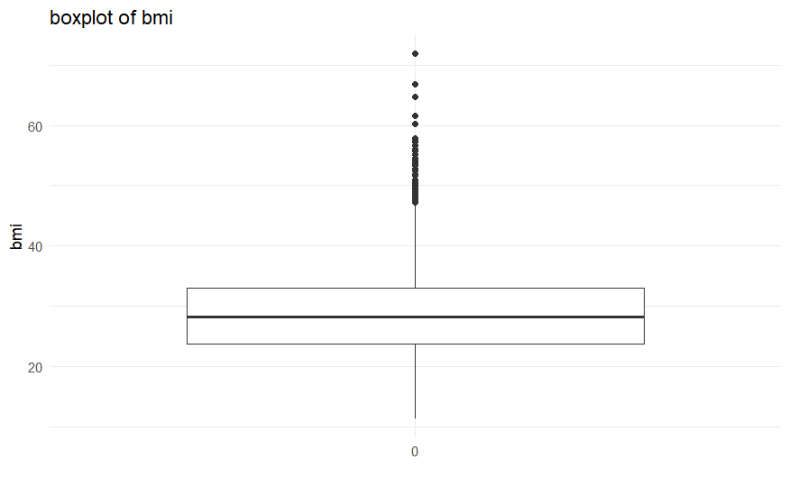

```r
for (col in numeric_columns) {
  p <- ggplot(tb_train, aes(x = factor(0), y = !!sym(col))) +
    geom_boxplot() +
    labs(title=glue('boxplot of {col}'),y = col, x = "") +
    theme_minimal()
  print(p)
}
```

Box-plots are very useful to notice outliers and are simple to make. As we discussed before, age is widely distributed and no point is really considered an outlier. The other two show many outliers on the upper side of the distribution, but since we already talked about them, and removing them when dealing with real patients may not always be a great idea, we’ll keep them in.